# Time Series Anaysis on FDIC SDI Dataset

#### Exponential smoothing method

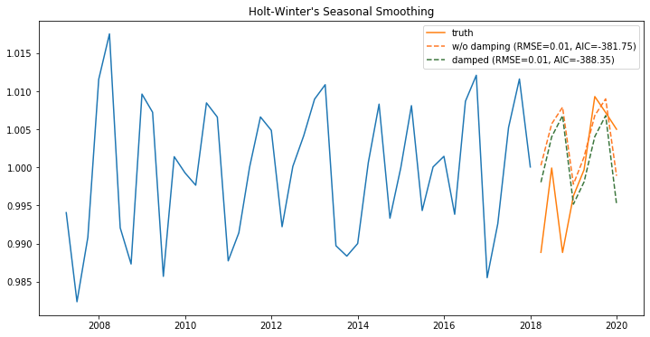

```python
from statsmodels.tsa.holtwinters import ExponentialSmoothing

train_st = deseasonalizedNet.ix[:-8]
test_st = deseasonalizedNet.ix[-8:]

model = ExponentialSmoothing(train_st, trend="add", seasonal="add", seasonal_periods=4)
model2 = ExponentialSmoothing(train_st, trend="add", seasonal="add", seasonal_periods=4, damped=True)
fit = model.fit()
pred = fit.forecast(8)
fit2 = model2.fit()
pred2 = fit2.forecast(8)

sse1 = np.sqrt(np.mean(np.square(test_st.values - pred.values)))
sse2 = np.sqrt(np.mean(np.square(test_st.values - pred2.values)))

fig, ax = plt.subplots(figsize=(12, 6))
ax.plot(train_st.index, train_st.values);
ax.plot(test_st.index, test_st.values, label='truth');
ax.plot(test_st.index, pred, linestyle='--', color='#ff7823', label="w/o damping (RMSE={:0.2f}, AIC={:0.2f})".format(sse1, fit.aic));
ax.plot(test_st.index, pred2, linestyle='--', color='#3c763d', label="damped (RMSE={:0.2f}, AIC={:0.2f})".format(sse2, fit2.aic));
ax.legend();
ax.set_title("Holt-Winter's Seasonal Smoothing");
```

RMSE as good as SARIMA model, and AIC is even lower, thus exponential smoothing is a little bit better for net asset prediction

### Conclusion for univariate model prediction

#### Detrend and Deseasonalize:

Detrending by deviding trend component/multiplicative performs better than substracting best fit on Net Asset data. Deseasonlizing improves stationary condition even more.

#### Exponential Smoothing (Holt-Winter's seasonal smoothing) Model:

Exponential Smoothing RMSE is as low as SARIMA at 0.01, and damped AIC is even lower to -388.35. Therefore exponential smoothing is better than SARIMA model prediction.

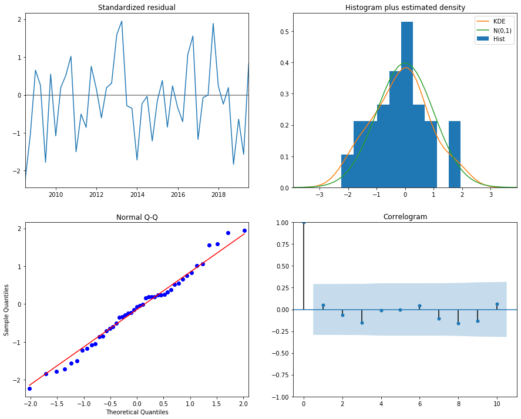

```python
# Test Stationary of ARIMA Model prediction results
sarima_fit.plot_diagnostics(figsize=(15, 12))
plt.show()
```

Residuals are fluctuate around 0, and KDE is almost normal distribution, normal Q-Q plot points and line are consistent, and correlogram are concentrated within the band. All these suggest the results of ARIMA model is stationary, useful for prediction.

### GARCH

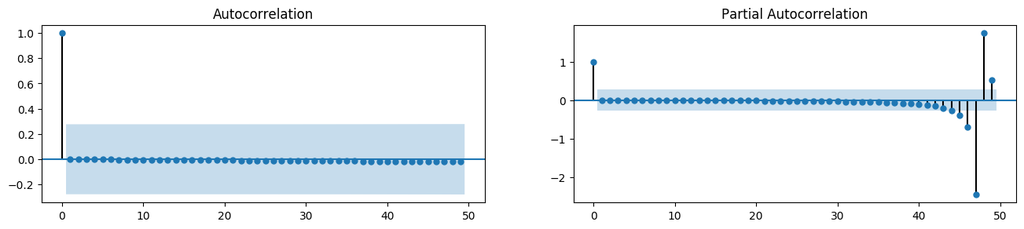

[figure not shown]

```python
# https://www.statsmodels.org/dev/generated/statsmodels.tsa.statespace.sarimax.SARIMAXResults.html
# sarima_fit.resid
fig, axes = plt.subplots(1,2,figsize=(16,3), dpi= 100)
square_results = sarima_fit.resid**2
plot_acf(square_results, lags=49, ax=axes[0])
plot_pacf(square_results, lags=49, ax=axes[1])
```

Since squared residuals shows constant variance over time, thus GARCH is not required.

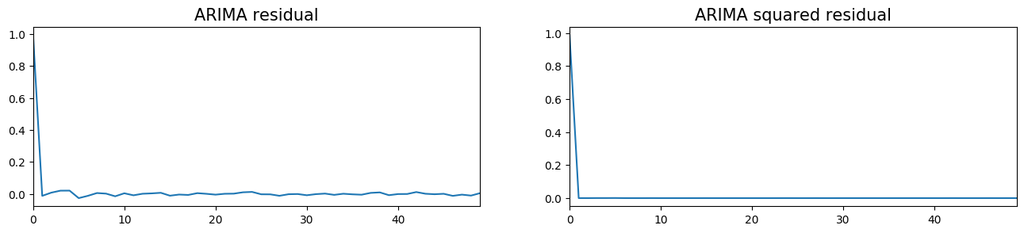

```python
# pip install tsplot
from seaborn import tsplot
fig, axes = plt.subplots(1,2,figsize=(16,3), dpi= 100)
tsplot(sarima_fit.resid,ax=axes[0])
tsplot(square_results,ax=axes[1])
axes[0].set_title('ARIMA residual', fontsize=15);
axes[1].set_title('ARIMA squared residual', fontsize=15);
```

### ARIMAX multivariate model

Although exponential smoothing model generates better prediction accuracy in the univariate model, it cannot include more than one x variable thus we choose ARIMAX model for multivariate x inputs.  
For ARIMAX multivariate model, we add dep (total deposits)& eeffr (efficiency ratio) as exogenous variables, they meet the assumption of ARIMAX that they all have causal relationship with net asset, while dep accounts for tangible asset and eeffr accounts for intangible asset.

Granger-causality test  
The test is whether the first variable is caused by the second variable.

```python
# sm.tsa.stattools.grangercausalitytests(dategroup[['netasset','dep']].dropna(),1)
sm.tsa.stattools.grangercausalitytests(dategroup[['dep','netasset']].dropna(),1).values
# sm.tsa.stattools.grangercausalitytests(dategroup[['netasset','eeffr']].dropna(),1)
sm.tsa.stattools.grangercausalitytests(dategroup[['eeffr','netasset']].dropna(),1).values
# sm.tsa.stattools.grangercausalitytests(dategroup[['offdom','netasset']].dropna(),1)
```

```
Granger Causality
number of lags (no zero) 1
ssr based F test:         F=5.3372  , p=0.0252  , df_denom=48, df_num=1
ssr based chi2 test:   chi2=5.6707  , p=0.0173  , df=1
likelihood ratio test: chi2=5.3771  , p=0.0204  , df=1
parameter F test:         F=5.3372  , p=0.0252  , df_denom=48, df_num=1

Granger Causality
number of lags (no zero) 1
ssr based F test:         F=6.1949  , p=0.0163  , df_denom=48, df_num=1
ssr based chi2 test:   chi2=6.5821  , p=0.0103  , df=1
likelihood ratio test: chi2=6.1907  , p=0.0128  , df=1
parameter F test:         F=6.1949  , p=0.0163  , df_denom=48, df_num=1
```

```
<function dict.values>
```

Granger-causality test verifies that there are causal relationships between net asset and dep, eeffr.

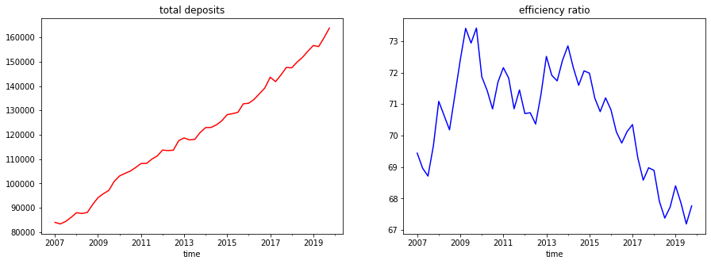

```python
fig, ax = plt.subplots(1,2,figsize=(15, 5))
dep = dategroup['dep']
eeffr = dategroup['eeffr']
dep.plot(ax=ax[0],color='red',title='total deposits')
eeffr.plot(ax=ax[1],color='blue',title='efficiency ratio')
plt.show()
```

dep is more trended, while eeffr is more seasonalized

```python
# dep
# ADF Test
print('dep: Stationarity test 5 ')
result = adfuller(dep, autolag='AIC')
print(f'ADF Statistic: {result[0]}')
print(f'p-value: {result[1]}')
for key, value in result[4].items():
    print('Critial Values:')
    print(f'   {key}, {value}')

# KPSS Test
result = kpss(dep, regression='c')
print('\nKPSS Statistic: %f' % result[0])
print('p-value: %f' % result[1])
for key, value in result[3].items():
    print('Critial Values:')
    print(f'   {key}, {value}')

# eeffr
# ADF Test
print('\neeffr: Stationarity test 5')
result = adfuller(eeffr, autolag='AIC')
print(f'ADF Statistic: {result[0]}')
print(f'p-value: {result[1]}')
for key, value in result[4].items():
    print('Critial Values:')
    print(f'   {key}, {value}')

# KPSS Test
result = kpss(eeffr, regression='c')
print('\nKPSS Statistic: %f' % result[0])
print('p-value: %f' % result[1])
for key, value in result[3].items():
    print('Critial Values:')
    print(f'   {key}, {value}')
```

```
dep: Stationarity test 5
ADF Statistic: 0.6789307245698107
p-value: 0.9894078794449231
Critial Values:
   1%, -3.584828853223594
Critial Values:
   5%, -2.9282991495198907
Critial Values:
   10%, -2.6023438271604937

KPSS Statistic: 0.564065
p-value: 0.027238
Critial Values:
   10%, 0.347
Critial Values:
   5%, 0.463
Critial Values:
   2.5%, 0.574
Critial Values:
   1%, 0.739

eeffr: Stationarity test 5
ADF Statistic: 0.5933619605063349
p-value: 0.9874508649610293
Critial Values:
   1%, -3.60098336718852
Critial Values:
   5%, -2.9351348158036012
Critial Values:
   10%, -2.6059629803688282

KPSS Statistic: 0.304553
p-value: 0.100000
Critial Values:
   10%, 0.347
Critial Values:
   5%, 0.463
Critial Values:
   2.5%, 0.574
Critial Values:
   1%, 0.739
```

None of dep or eeffr is stationary at the beginning.

#### Detrending & Deseasonalizing

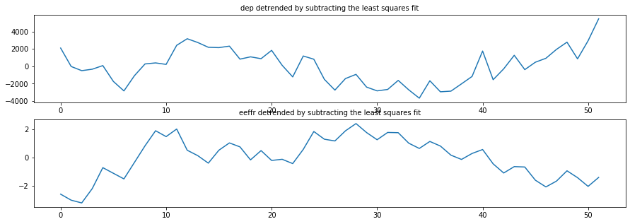

```python
# substracting best fit method
depdetrended1 = signal.detrend(dep.values)
eeffrdetrended1 = signal.detrend(eeffr.values)

f = plt.figure(figsize=(15, 5))
f.add_subplot(2,1, 1)
plt.plot(depdetrended1)
plt.title('dep detrended by subtracting the least squares fit', fontsize=10)
f.add_subplot(2,1, 2)
plt.plot(eeffrdetrended1)
plt.title('eeffr detrended by subtracting the least squares fit', fontsize=10)
```

```python
# dep
# ADF Test
print('dep: Stationarity test 6 ')
result = adfuller(depdetrended1, autolag='AIC')
print(f'ADF Statistic: {result[0]}')
print(f'p-value: {result[1]}')
for key, value in result[4].items():
    print('Critial Values:')
    print(f'   {key}, {value}')

# KPSS Test
result = kpss(depdetrended1, regression='c')
print('\nKPSS Statistic: %f' % result[0])
print('p-value: %f' % result[1])
for key, value in result[3].items():
    print('Critial Values:')
    print(f'   {key}, {value}')

# eeffr
# ADF Test
print('\neeffr: Stationarity test 6')
result = adfuller(eeffrdetrended1, autolag='AIC')
print(f'ADF Statistic: {result[0]}')
print(f'p-value: {result[1]}')
for key, value in result[4].items():
    print('Critial Values:')
    print(f'   {key}, {value}')

# KPSS Test
result = kpss(eeffrdetrended1, regression='c')
print('\nKPSS Statistic: %f' % result[0])
print('p-value: %f' % result[1])
for key, value in result[3].items():
    print('Critial Values:')
    print(f'   {key}, {value}')
```

```
dep: Stationarity test 6
ADF Statistic: -2.2129709972311233
p-value: 0.20157146038755924
Critial Values:
   1%, -3.6055648906249997
Critial Values:
   5%, -2.937069375
Critial Values:
   10%, -2.606985625

KPSS Statistic: 0.105694
p-value: 0.100000
Critial Values:
   10%, 0.347
Critial Values:
   5%, 0.463
Critial Values:
   2.5%, 0.574
Critial Values:
   1%, 0.739

eeffr: Stationarity test 6
ADF Statistic: -0.6513795489266956
p-value: 0.8589447305567098
Critial Values:
   1%, -3.596635636000432
Critial Values:
   5%, -2.933297331821618
Critial Values:
   10%, -2.6049909750566895

KPSS Statistic: 0.156512
p-value: 0.100000
Critial Values:
   10%, 0.347
Critial Values:
   5%, 0.463
Critial Values:
   2.5%, 0.574
Critial Values:
   1%, 0.739
```

Results are not stationary

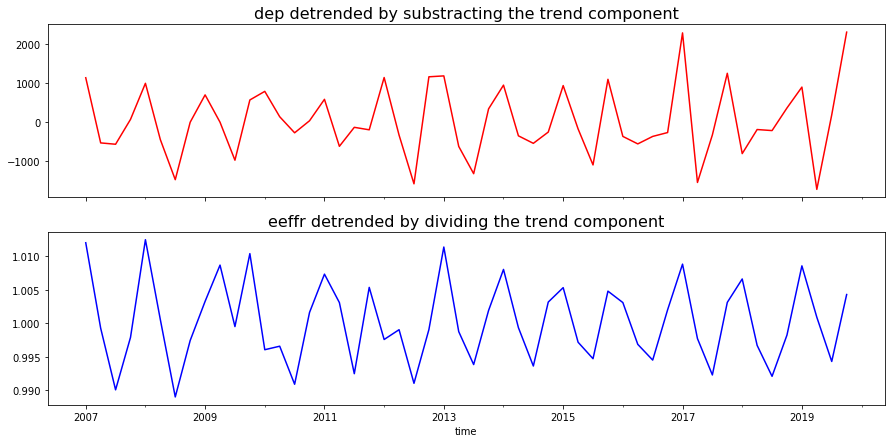

```python
# Decompose method
fig, ax = plt.subplots(2,figsize=(15,7),sharex=True)


# result_mul2 = seasonal_decompose(dep, model='multiplicative', extrapolate_trend='freq')
# depdetrended2 = dep.values / result_mul2.trend
# depdetrended2.plot(ax=ax[0],color='blue')
# ax[0].set_title('dep detrended by dividing the trend component', fontsize=16);

result_mul2 = seasonal_decompose(dep, model='additive', extrapolate_trend='freq')
depdetrended2a = dep.values - result_mul2.trend
depdetrended2a.plot(ax=ax[0],color='red')
ax[0].set_title('dep detrended by substracting the trend component', fontsize=16);

result_mul2 = seasonal_decompose(eeffr, model='multiplicative', extrapolate_trend='freq')
eeffrdetrended2 = eeffr.values / result_mul2.trend
eeffrdetrended2 .plot(ax=ax[1],color='blue')
ax[1].set_title('eeffr detrended by dividing the trend component', fontsize=16);

# result_mul2a = seasonal_decompose(eeffr, model='additive', extrapolate_trend='freq')
# eeffrdetrended2a =eeffr.values - result_mul2a.trend
# eeffrdetrended2a.plot(ax=ax[1],color='red')
# ax[3].set_title('eeffr detrended by subtracting the trend component', fontsize=16);
```

```python
# dep - additive is better
# ADF Test
print('dep: Stationarity test 6 - detrend')
result = adfuller(depdetrended2a, autolag='AIC')
print(f'ADF Statistic: {result[0]}')
print(f'p-value: {result[1]}')
for key, value in result[4].items():
    print('Critial Values:')
    print(f'   {key}, {value}')

# KPSS Test
result = kpss(depdetrended2a, regression='c')
print('\nKPSS Statistic: %f' % result[0])
print('p-value: %f' % result[1])
for key, value in result[3].items():
    print('Critial Values:')
    print(f'   {key}, {value}')

# eeffr - multiplicative is better
# ADF Test
print('\neeffr: Stationarity test 6 -detrend')
result = adfuller(eeffrdetrended2, autolag='AIC')
print(f'ADF Statistic: {result[0]}')
print(f'p-value: {result[1]}')
for key, value in result[4].items():
    print('Critial Values:')
    print(f'   {key}, {value}')

# KPSS Test
result = kpss(eeffrdetrended2, regression='c')
print('\nKPSS Statistic: %f' % result[0])
print('p-value: %f' % result[1])
for key, value in result[3].items():
    print('Critial Values:')
    print(f'   {key}, {value}')
```

```
dep: Stationarity test 6 - detrend
ADF Statistic: -4.350398971738615
p-value: 0.00036293451564887964
Critial Values:
   1%, -3.596635636000432
Critial Values:
   5%, -2.933297331821618
Critial Values:
   10%, -2.6049909750566895

KPSS Statistic: 0.217169
p-value: 0.100000
Critial Values:
   10%, 0.347
Critial Values:
   5%, 0.463
Critial Values:
   2.5%, 0.574
Critial Values:
   1%, 0.739

eeffr: Stationarity test 6 -detrend
ADF Statistic: -2.786659192738173
p-value: 0.06020482121339439
Critial Values:
   1%, -3.5885733964124715
Critial Values:
   5%, -2.929885661157025
Critial Values:
   10%, -2.6031845661157025

KPSS Statistic: 0.200038
p-value: 0.100000
Critial Values:
   10%, 0.347
Critial Values:
   5%, 0.463
Critial Values:
   2.5%, 0.574
Critial Values:
   1%, 0.739
```

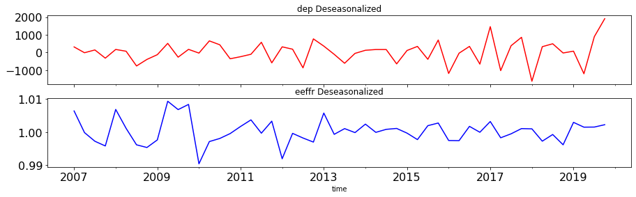

```python
# Deseasonalizing
result_mul = seasonal_decompose(depdetrended2a, model='additive', freq=4)
result_mule = seasonal_decompose(eeffrdetrended2, model='multiplicative', freq=4)
deseasonalizeddep = depdetrended2a.tolist() - result_mul.seasonal
deseasonalizedeeffr = eeffrdetrended2.tolist() / result_mule.seasonal
# Plot
fig, ax = plt.subplots(2,figsize=(15,4),sharex=True)
deseasonalizeddep.plot(ax=ax[0],title ='dep Deseasonalized',fontsize=16,color='red' )
deseasonalizedeeffr.plot(ax=ax[1],title ='eeffr Deseasonalized',fontsize=16,color='blue' )
```

```python
# dep
# ADF Test
print('dep: Stationarity test 7 - deseasonalize')
result = adfuller(deseasonalizeddep, autolag='AIC')
print(f'ADF Statistic: {result[0]}')
print(f'p-value: {result[1]}')
for key, value in result[4].items():
    print('Critial Values:')
    print(f'   {key}, {value}')

# KPSS Test
result = kpss(deseasonalizeddep, regression='c')
print('\nKPSS Statistic: %f' % result[0])
print('p-value: %f' % result[1])
for key, value in result[3].items():
    print('Critial Values:')
    print(f'   {key}, {value}')

# eeffr - multiplicative is better
# ADF Test
print('\neeffr: Stationarity test 7 - deseasonalize')
result = adfuller(deseasonalizedeeffr, autolag='AIC')
print(f'ADF Statistic: {result[0]}')
print(f'p-value: {result[1]}')
for key, value in result[4].items():
    print('Critial Values:')
    print(f'   {key}, {value}')

# KPSS Test
result = kpss(deseasonalizedeeffr, regression='c')
print('\nKPSS Statistic: %f' % result[0])
print('p-value: %f' % result[1])
for key, value in result[3].items():
    print('Critial Values:')
    print(f'   {key}, {value}')
```

```
dep: Stationarity test 7 - deseasonalize
ADF Statistic: -2.8762608350453083
p-value: 0.048179000800855715
Critial Values:
   1%, -3.5778480370438146
Critial Values:
   5%, -2.925338105429433
Critial Values:
   10%, -2.6007735310095064

KPSS Statistic: 0.222504
p-value: 0.100000
Critial Values:
   10%, 0.347
Critial Values:
   5%, 0.463
Critial Values:
   2.5%, 0.574
Critial Values:
   1%, 0.739

eeffr: Stationarity test 7 - deseasonalize
ADF Statistic: -4.535304871381527
p-value: 0.00016968791755185038
Critial Values:
   1%, -3.5778480370438146
Critial Values:
   5%, -2.925338105429433
Critial Values:
   10%, -2.6007735310095064

KPSS Statistic: 0.115531
p-value: 0.100000
Critial Values:
   10%, 0.347
Critial Values:
   5%, 0.463
Critial Values:
   2.5%, 0.574
Critial Values:
   1%, 0.739
```

Both dep and eeffr are stationary at 5% significance level now.